# Cortical proximity, not structural communication, organises atrophy in Alzheimer’s disease and frontotemporal dementia

with a long-range functional component specific to frontotemporal dementia

[Authors]

Revised manuscript — 21 November 2026

**Background.** Atrophy in neurodegenerative dementias is often said to follow the connectome, but connectomes and atrophy maps are both organised by distance, and the null models used to test network effects differ in what they preserve. We asked whether any structural communication model explains atrophy beyond spatial proximity in Alzheimer’s disease (AD) and frontotemporal dementia (FTD), two cortical diseases with distinct topographies.

**Methods.** Open group-level deformation-based morphometry maps of AD, MCI, FTD and its behavioural (bvFTD), semantic (svPPA) and non-fluent (nfvPPA) variants were parcellated into 400 cortical regions (100 and 200 for robustness) and 14 subcortical structures with atlases nonlinearly registered to the maps’ template. We predicted each region’s atrophy from all other regions using the Human Connectome Project structural connectome (direct connections, shortest paths, communicability, search information, navigation, diffusion), functional connectivity, generative network diffusion from seeds, and Euclidean and geodesic spatial kernels, with five null models (spin, variogram-matched, Moran spectral randomisation, degree- and geometry-preserving rewiring) and all parameters refitted inside every null.

**Results.** A geodesic spatial kernel predicted atrophy best in every syndrome (AD r = 0.80, bvFTD r = 0.79) and outperformed the Euclidean kernel. No structural communication model exceeded the spatial baselines or survived the variogram-matched null in any syndrome, including after adding the subcortex, and seeded network diffusion on the structural connectome was never better than spatial spread from the same seed. When only regions more than 30 mm away were allowed, thresholded functional connectivity predicted atrophy in bvFTD (r = 0.72) and FTD (r = 0.65) under every null; in AD the unique long-range functional contribution beyond distance was about half as large (partial r = 0.33 vs 0.67). Degree-preserving rewiring supported every structural fit and spins about a third; variogram-matched surrogates supported none.

**Conclusions.** Cortical atrophy in AD and FTD is organised mainly by proximity along the cortical sheet; structural communication models add little beyond that geometry. FTD, particularly bvFTD, additionally follows the long-range functional architecture. Network claims about atrophy should be tested against fitted spatial baselines and geometry-preserving nulls.

# Introduction

Alzheimer’s disease (AD) and frontotemporal dementia (FTD) are both cortical neurodegenerative diseases, but their atrophy follows very different spatial patterns. AD involves the medial temporal lobe, the posterior cingulate/precuneus and lateral temporoparietal cortex; behavioural-variant FTD involves orbitofrontal, anterior cingulate and anterior insular cortex; the language variants of FTD are left-lateralised, in the anterior temporal lobe (semantic variant) or the posterior frontal and insular cortex (non-fluent variant). The network-degeneration hypothesis proposes that these patterns are shaped by the brain’s connectivity: atrophy maps resemble intrinsic connectivity networks [1], regions connected to an epicentre are more affected [2, 5], and network spreading models reproduce group and individual patterns [3, 6, 7, 10].

Two methodological issues limit how much these findings say about networks. First, atrophy maps and connectomes are both spatially smooth and both organised by distance: nearby regions tend to be connected and tend to have similar atrophy. A network model can therefore predict atrophy well simply because connections are short [13, 23]. Few studies compare network models with a purely spatial model that has the same freedom [8, 9, 11]. Second, the null models used to test network effects differ in what they preserve. Spatial permutation (“spin”) tests preserve the map’s spatial autocorrelation only approximately [19], and degree-preserving rewiring of the connectome destroys its geometry, so that almost any spatially smooth map looks network-constrained.

The structural connectome supports many candidate routes of communication, from direct connections and shortest paths to diffusion, search-information and navigation models [12–15]. Which of these, if any, best explains atrophy, and whether the answer differs between diseases with different spatial patterns, has not been tested. Here we compared these communication models, functional connectivity and generative spreading models with Euclidean and along-the-cortex (geodesic) spatial baselines, in AD, MCI and the FTD syndromes, using openly shared atrophy maps, cortical and subcortical parcellations registered to the templates of the maps, and five null models with all parameters refitted inside every null. We asked three questions: does any network model explain atrophy beyond spatial proximity; is the answer different for AD and FTD; and how much do conclusions depend on the null model.

# Methods

## Atrophy maps

We used openly shared, group-level deformation-based morphometry (DBM) maps comparing patients with matched controls on the ICBM152 2009c nonlinear symmetric template (1 mm) [29, 30, 32]: Alzheimer’s disease (AD) and mild cognitive impairment (MCI) from ADNI, and frontotemporal dementia (FTD; pooled) and its clinical variants (behavioural-variant FTD, bvFTD; semantic-variant primary progressive aphasia, svPPA; non-fluent variant, nfvPPA) from NIFD/FTLDNI (Zenodo 10.5281/zenodo.7392621 and 10.5281/zenodo.10383493, CC-BY-4.0). The source study reports 212 AD, 551 MCI and 125 FTD patients and 571 controls across cohorts, modelled with mixed-effects models [29]; sample sizes for the variant maps were not reported in the record. The variant maps span a much smaller numerical range (about ±1.5) than the pooled FTD map (about ±16) and may therefore not be t-statistics. We have asked the map authors to confirm the statistic, the sample sizes, whether the variant maps share controls, and the model covariates and smoothing. Until this is confirmed we do not interpret absolute values of the variant maps or compare them across maps: every analysis below is invariant to linear rescaling, and each map is displayed on its own colour scale. We define atrophy as −t, so that larger values mean more volume loss. The three variant maps are likely to share one control group, which inflates their mutual similarity; between-syndrome similarity is therefore reported only descriptively. Parkinson’s disease, available in the same record, was not analysed. No map of dementia with Lewy bodies was available.

## Parcellation and template registration

Cortex was parcellated with the Schaefer 2018 atlas (7 networks; 400 parcels primary, 200 and 100 for robustness) [25]; subcortex with the Tian S1 atlas [26], whose 16 regions were mapped onto the 14 structures of the ENIGMA connectomes (accumbens, amygdala, caudate, hippocampus, pallidum, putamen and thalamus per hemisphere; anterior and posterior thalamus merged) [27]. Both atlases are defined on FSL MNI152 (MNI152NLin6Asym), whereas the atrophy maps are on ICBM152 2009c symmetric. We therefore registered the FSL MNI152 1 mm brain to the ICBM 2009c symmetric brain (skull-stripped with the DBM brain mask) with ANTs symmetric normalisation (SyN) [31] and warped both atlases with nearest-label interpolation onto the grid of the maps. Registration raised the intensity correlation between the two templates from 0.74 (world-coordinate resampling) to 0.91; 30% of cortical voxels changed parcel at 400 parcels (Supplementary Table S1).

Parcel values are mean −t within the parcel. Because DBM maps encode ventricular and sulcal expansion that spreads into neighbouring tissue through smoothing, subcortical values were taken from the core of each structure (voxels ≥ 3 mm from template CSF), which removed spill-over that made the AD hippocampus appear only mildly atrophic (mean −t 1.6 with all voxels, 3.0 in the core). The caudate remained dominated by ventricular expansion and is flagged throughout. All parcels had ≥ 86% voxel coverage.

## Connectomes and distances

Group-level structural (SC) and functional (FC) connectivity from the Human Connectome Project were taken from the ENIGMA toolbox for Schaefer-100/200/400 (cortex) and Schaefer-400 with the 14 subcortical structures [27, 28]; label orders were verified to match the atlases exactly. Negative SC weights (14 edges at 400 parcels; 20 with subcortex) were set to zero. FC (negative values already set to zero upstream, density 97–99%) was used in full and after proportional thresholding to its strongest 20% and 10% of edges.

Euclidean distances were computed between parcel centroids in ICBM 2009c space. Geodesic distances along the cortical midthickness surface (fsaverage5, medial wall removed) were computed between parcel centroid vertices with the heat method [33] (validated against the analytic pole-to-pole distance on the sphere: 312 vs 314 mm); pairs in different hemispheres have no cortical path.

## Predicting atrophy from other regions

For a weighting matrix M, the predicted atrophy of node i is the weighted mean of all other nodes, P_i = Σ_{j≠i} M_ij a_j / Σ_{j≠i} M_ij, and the fit is r(a, P). With M = SC or FC this is the neighbour atrophy of Zeighami et al. and Shafiei et al. [4, 5]. We compared: (i) direct SC; (ii) five communication models on the SC [13]: shortest-path efficiency, weighted communicability [15], search information (as the shortest-path probability 2^−SI) [14], navigation efficiency with Euclidean greedy routing [12] and diffusion efficiency (1/mean first-passage time); (iii) the network diffusion (heat) kernel e^{−βL} [3], β fitted; (iv) FC (full, top 20%, top 10%); and two spatial baselines, (v) a Euclidean and (vi) a geodesic distance kernel e^{−d/λ}, λ fitted. As a sensitivity analysis every communication model received one fitted exponent (M^γ), matching the single parameter of the baselines.

Because a short-range kernel applied to a smooth map acts as spatial interpolation, we also evaluated **distance-censored prediction**: all pairs closer than R mm (Euclidean; R = 10–60 mm) were removed from every model, so that a node’s atrophy must be predicted from distant nodes. Euclidean censoring is the conservative choice because volumetric smoothing acts in Euclidean space and geodesic distances always exceed it within a hemisphere. The **unique contribution** of a model beyond distance was measured as the partial correlation r(a, P_M | P_distance), with λ refitted for every map and surrogate.

## Generative spreading from seeds

To evaluate spreading models in their generative form [3, 11], we seeded each model at every node, alone and together with its contralateral homologue, and predicted the whole map: network diffusion x(t) = e^{−Lt} x₀ on the SC (NDM-SC) or on the FC (NDM-FC), with L the normalised graph Laplacian and t over 25 values (0.05–50), and isotropic spatial spread e^{−d/λ} x₀ from the same seeds, in Euclidean or geodesic distance. For each model the best seed and parameter were selected by maximising r(a, x).

## Null models and inference

Five null models were used. Three preserve the spatial autocorrelation of the map: spins of the cortical surface with Hungarian reassignment [17–19] (subcortical nodes permuted among themselves), variogram-matched surrogates [20] and Moran spectral randomisation [21]. Two replace the SC while keeping the map: degree-preserving rewiring [22] and degree- and geometry-preserving rewiring, in which swaps are accepted only within edge-length bins [23]. Every fitted parameter (λ, β, γ, t, best seed) was refitted inside each of the 1,000 surrogates or rewired networks per null. p-values are one-sided (null ≥ observed) for fits and two-sided for paired differences between models; false discovery rate (FDR, Benjamini–Hochberg) was controlled across syndromes × models within each null and radius. A result was counted as evidence of a positive network constraint only if r > 0 and FDR q < 0.05. Because geometry-preserving rewiring saturates at about 50% edge turnover, we also report how it depends on the bin width (5–40 bins).

## Additional analyses

**Epicentres.** Nodes were ranked by the mean of their rank on atrophy and on SC-neighbour atrophy [5], with spin and rewiring p-values. **Asymmetry.** Because Schaefer parcels are not left–right homologous, each left parcel was compared with the identical region mirrored to the right: the symmetric template allows the voxel map to be mirrored and re-parcellated with the same atlas. **Hubs.** Node strength (SC; FC full and thresholded) was correlated with atrophy (Spearman), with and without controlling for regional EPI signal (SPM12 mean EPI template), a proxy for susceptibility dropout in orbitofrontal and anterior temporal cortex [35]. **Eigenmodes.** Atrophy was reconstructed from the first K eigenmodes of the cortical surface (Laplace–Beltrami, fsaverage5) [24] and of the SC and FC graph Laplacians, computed within each hemisphere so that all bases have the same structure.

## Software and validation

Analyses used R 4.3 and Python 3.13. Network measures were implemented in an R package with C++ kernels and validated against bctpy 0.6.1 and netneurotools 0.3.0 on the HCP Schaefer-400 SC (maximum absolute difference ≤ 5×10⁻¹¹); spin permutations were validated against neuromaps 0.0.7 (Supplementary Tables S2–S4). Code, intermediate data and validation reports are available at the project repository.

# Results

## Two distinct atrophy topographies

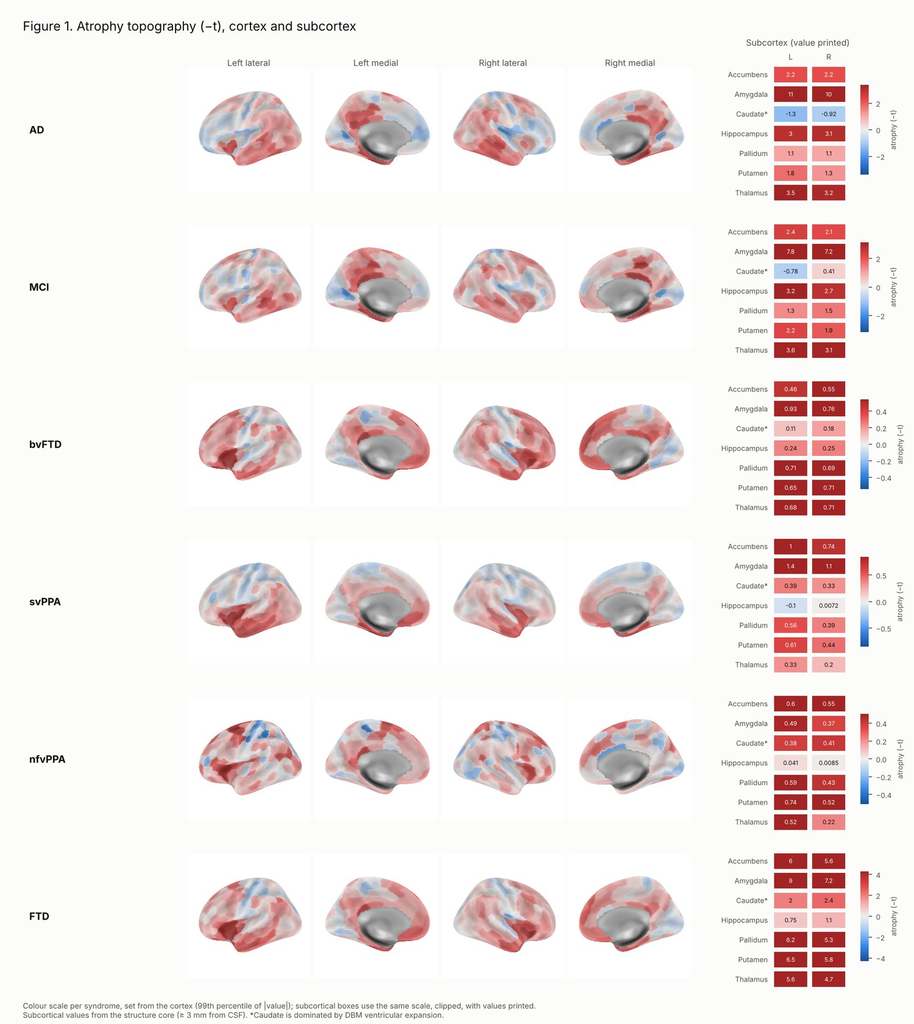

**Figure 1. Atrophy topographies.** Group-level DBM atrophy (−t) on the cortex (Schaefer-400, warped to the template of the maps) and in 14 subcortical structures. Colour scale set per syndrome from the cortex; subcortical boxes print their values. *Caudate is dominated by DBM ventricular expansion.

AD and MCI atrophy involved the medial temporal lobe, the posterior cingulate/precuneus and lateral temporoparietal cortex; in the subcortex the amygdala was the most affected structure (AD: 11.21 left, 10.15 right), followed by the thalamus and hippocampus. bvFTD involved orbitofrontal, anterior insular, anterior cingulate and dorsomedial prefrontal cortex with diffuse striatal and thalamic involvement; svPPA the anterior temporal lobe and nfvPPA the posterior frontal, opercular and supplementary motor cortex (Figure 1). AD and bvFTD maps were only moderately similar (r = 0.41), whereas AD and MCI were strongly similar (r = 0.84; Supplementary Table S5).

**Asymmetry.** Comparing each left region with the identical mirrored right region, AD, MCI and bvFTD were symmetric (proportion of the most atrophic locations that were left-dominant: AD 0.57, bvFTD 0.38; sign tests p = 0.358 and p = 0.144), whereas svPPA (0.88, p < 0.001) and nfvPPA (0.72, p < 0.001) were left-lateralised. The left-dominant anterior insula seen in the raw bvFTD parcellation arises in two steps: Schaefer’s left and right ventral prefrontal/insular parcels differ in size and position, so the raw left parcel is more atrophic than the raw right parcel; but when the same left parcel samples the mirrored map, its value does not drop, so the difference is not a hemispheric difference in the disease (Supplementary Figure S2).

## Atrophy is organised along the cortical sheet

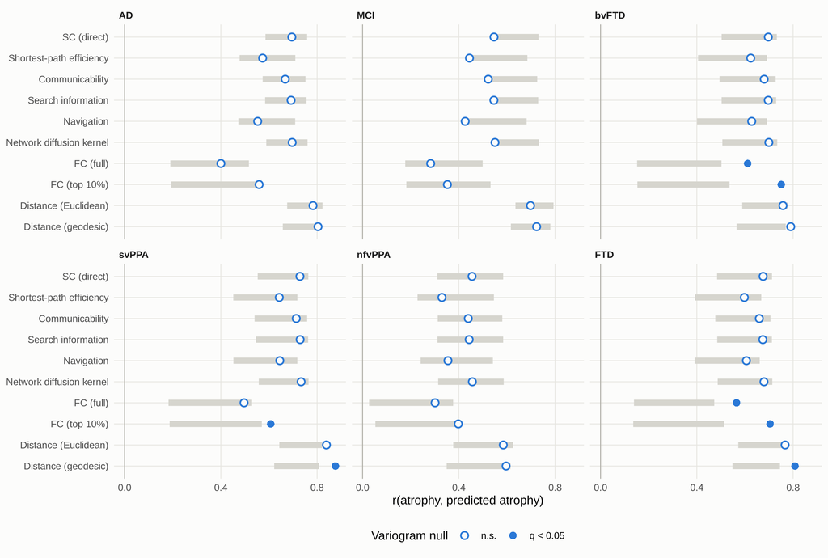

**Figure 2. Predicting each region’s atrophy from all other regions (Schaefer-400 cortex).** Dots: r(atrophy, prediction). Filled dots: significant against the variogram-matched null (FDR q < 0.05, r > 0). Grey bars: central 95% of the variogram null for each model (parameters refitted). The two spatial baselines (bottom) use Euclidean or geodesic distance; network models use the structural (SC) or functional (FC) connectome.

## A long-range functional component specific to frontotemporal dementia

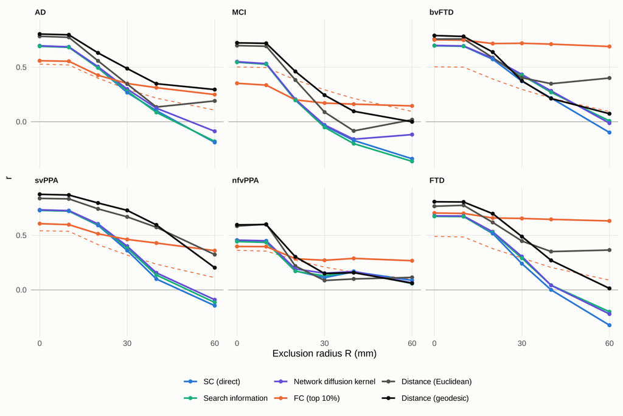

**Figure 3. Distance-censored prediction.** Each model may use only regions further than R mm (Euclidean) from the target. Lines: r(atrophy, prediction) at each radius. Dashed: 95th percentile of the variogram null for thresholded FC (top 10%).

When nearby regions were excluded, the picture separated by disease (Figure 3). With only regions more than 30 mm away, thresholded FC predicted bvFTD atrophy at r = 0.72 and pooled FTD at r = 0.65 (variogram q = 0.007 for bvFTD and q = 0.007 for FTD; also significant against spins and Moran surrogates), far above both distance kernels (bvFTD geodesic r = 0.38). The corresponding values were r = 0.46 in svPPA and 0.27 in nfvPPA, but only 0.35 in AD and 0.17 in MCI. Beyond distance, FC added a unique contribution in bvFTD (partial r = 0.67, variogram p < 0.001) and pooled FTD (0.60) that was about half as large in AD (0.33, variogram p < 0.001) and smaller still in MCI (0.16; Supplementary Table S8). Among structural models only bvFTD retained a smaller long-range contribution beyond distance (search information partial r = 0.27, variogram q = 0.014). Full-density FC behaved like thresholded FC but weaker (bvFTD r = 0.53).

## Generative spreading: no advantage for the structural connectome

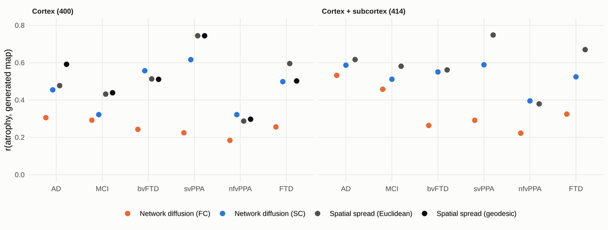

**Figure 4. Generative models seeded at the best node (or bilateral pair).** Network diffusion on the SC or FC versus isotropic spatial spread (Euclidean or geodesic) from the seed, cortex only (left) and with subcortex (right). Seed and parameter refitted in every null surrogate.

Seeded network diffusion on the SC was never better than isotropic spatial spread from the same seed (Figure 4). In AD, the best cortical seeds were bilateral anterior/medial temporal parcels, and geodesic spread from them explained the map better than diffusion along the SC (r = 0.59 vs 0.45; difference variogram p = 0.025). With the subcortex included, every model chose the bilateral amygdala as the AD seed, and SC diffusion (r = 0.59) and spatial spread (r = 0.62) were indistinguishable. In bvFTD, SC diffusion from a left ventrolateral prefrontal seed and spatial spread performed equally (r = 0.56 and 0.51). FC-based diffusion from a single seed performed poorly in every syndrome, in contrast to the static FC-neighbour models above: the FC signal in FTD reflects the distributed functional network rather than spread from one focus.

## Adding the subcortex does not rescue the structural connectome in AD

With 14 subcortical structures added (414 nodes), the structural models still failed the variogram null in AD (search information r = 0.63, p = 0.613) and carried no long-range signal (R = 30 mm: r = 0.23). Thresholded FC gained a modest long-range contribution in AD (r = 0.36, variogram p = 0.013), still well below bvFTD (r = 0.74) and pooled FTD (r = 0.69).

## Functional hubs and signal dropout

**Table 1. FC node strength and atrophy (Spearman), raw and controlling for regional EPI signal (dropout proxy).** Schaefer-400 cortex; p from 1,000 spins.

| Strength | Syndrome | rho | p (spin) | rho \| EPI signal | p (spin) \| EPI | rho(strength, EPI) |
| --- | --- | --- | --- | --- | --- | --- |
| FC (full) | AD | -0.15 | = 0.451 | -0.18 | = 0.321 | -0.16 |
| FC (full) | MCI | -0.26 | = 0.026 | -0.27 | = 0.020 | -0.16 |
| FC (full) | bvFTD | -0.63 | < 0.001 | -0.62 | < 0.001 | -0.16 |
| FC (full) | svPPA | -0.44 | = 0.022 | -0.43 | = 0.020 | -0.16 |
| FC (full) | nfvPPA | -0.26 | = 0.008 | -0.26 | = 0.003 | -0.16 |
| FC (full) | FTD | -0.65 | < 0.001 | -0.64 | < 0.001 | -0.16 |
| FC (top 10%) | AD | -0.05 | = 0.826 | -0.09 | = 0.670 | -0.26 |
| FC (top 10%) | MCI | -0.21 | = 0.079 | -0.23 | = 0.044 | -0.26 |
| FC (top 10%) | bvFTD | -0.44 | = 0.002 | -0.43 | < 0.001 | -0.26 |
| FC (top 10%) | svPPA | -0.41 | = 0.101 | -0.39 | = 0.088 | -0.26 |
| FC (top 10%) | nfvPPA | -0.21 | = 0.031 | -0.21 | = 0.016 | -0.26 |
| FC (top 10%) | FTD | -0.52 | < 0.001 | -0.51 | < 0.001 | -0.26 |

Regions with high FC strength were less atrophic in bvFTD and pooled FTD, with full-density and with thresholded FC (Table 1), whereas SC strength was weakly positively related to bvFTD atrophy (ρ = 0.28). Regional EPI signal, our proxy for susceptibility dropout, was lowest in orbitofrontal and anterior temporal cortex (limbic network 0.87 of the cortical median), but it was only weakly related to FC strength (ρ = -0.16), and partialling it out left the bvFTD association unchanged (ρ = -0.63 → -0.62). This proxy, a template from a different scanner and sequence, cannot exclude HCP-specific dropout, and low FC strength is also a known property of limbic and orbitofrontal networks. We therefore report the association without interpreting it as sparing of functional hubs.

## The choice of null model decides significance

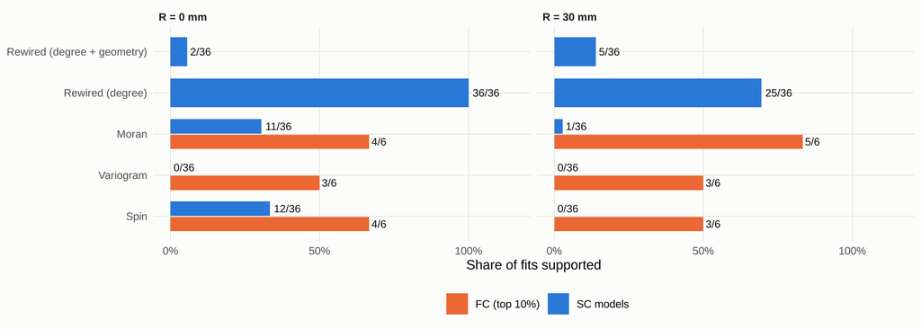

**Figure 5. Number of model fits with a positive network constraint (r > 0, FDR q < 0.05) under each null.** Schaefer-400 cortex; SC models (direct, shortest-path, communicability, search information, navigation, diffusion kernel) and thresholded FC, six syndromes, at R = 0 and 30 mm.

Whether a structural model appeared to constrain atrophy depended mostly on the null (Figure 5). Degree-preserving rewiring supported almost every structural fit, because it roughly doubles the mean connection length and so destroys the spatial embedding that the real connectome shares with atrophy. Spins supported about a third of structural fits at R = 0, because parcel-level spins make surrogate maps rougher at short range than the real map (short-range variogram ratio 1.03–1.42 times the empirical value, vs 0.80–0.95 for Moran surrogates, which are slightly smoother than the real maps; Supplementary Table S9). Variogram-matched surrogates supported no structural fit and geometry-preserving rewiring very few, whereas the thresholded-FC result in bvFTD and FTD survived every spatial null.

## Eigenmodes within each hemisphere

**Table 2. Reconstruction of atrophy from the first K eigenmodes, computed within each hemisphere** (mean r of the two hemispheres). Geometric = Laplace–Beltrami modes of the hemisphere’s cortical surface; SC/FC = harmonics of that hemisphere’s SC or FC graph.

| syndrome | K | FC harmonics | Geometric | SC harmonics |
| --- | --- | --- | --- | --- |
| AD | 10 | 0.49 | 0.67 | 0.54 |
| MCI | 10 | 0.35 | 0.55 | 0.38 |
| bvFTD | 10 | 0.67 | 0.61 | 0.62 |
| svPPA | 10 | 0.59 | 0.80 | 0.62 |
| nfvPPA | 10 | 0.43 | 0.38 | 0.38 |
| FTD | 10 | 0.65 | 0.66 | 0.57 |
| AD | 20 | 0.66 | 0.76 | 0.73 |
| MCI | 20 | 0.57 | 0.65 | 0.61 |
| bvFTD | 20 | 0.77 | 0.76 | 0.74 |
| svPPA | 20 | 0.80 | 0.85 | 0.78 |
| nfvPPA | 20 | 0.54 | 0.54 | 0.54 |
| FTD | 20 | 0.77 | 0.79 | 0.74 |

When all bases were computed within each hemisphere, geometric eigenmodes reconstructed AD and MCI atrophy at least as well as connectome harmonics, whereas FC harmonics reconstructed bvFTD best at low K (Table 2), in line with the static and censored analyses.

## Robustness

The main results were unchanged at 200 and 100 parcels (Supplementary Table S10): no structural model exceeded the distance baseline, and the long-range FC effect in bvFTD and pooled FTD remained significant against the variogram null.

# Discussion

We asked whether the structural connectome, through any of its candidate communication routes, explains cortical atrophy in AD and FTD beyond spatial proximity, and whether the answer differs between these two spatially distinct diseases. Three findings stand out.

**First, proximity along the cortex explains most of the atrophy topography in both diseases.** A single-parameter spatial kernel predicted each region’s atrophy from other regions better than any structural communication model, and geodesic distance did better than Euclidean distance. This argues against the concern that a Euclidean baseline is inflated by bridging sulci and fissures: the smoothness of atrophy follows the cortical sheet. This is compatible with several mechanisms that our data cannot separate, including spread between neighbouring cortical columns, shared vulnerability of neighbouring regions with similar cytoarchitecture and gene expression, and the spatial smoothing inherent in DBM and group statistics.

**Second, the structural connectome adds little beyond its own geometry.** Direct connections, shortest paths, communicability, search information, navigation and network diffusion all correlated with atrophy, but none survived a null that preserves the map’s spatial autocorrelation (variogram-matched surrogates) or one that preserves the connectome’s wiring geometry (with a bin-width-dependent exception for path-based models in bvFTD), and none outperformed the distance kernel, including when given the same freedom to fit. Seeded network diffusion on the SC, evaluated in its generative form as recommended, was never better than isotropic spread from the same seed. Adding the hippocampus, amygdala, thalamus and striatum did not change this in AD, although every AD model chose the bilateral amygdala as the seed. The only structural signal beyond geometry was in bvFTD: path-based models survived geometry-preserving rewiring with coarse bins, and search information retained a small long-range contribution beyond distance. These results do not show that pathology does not travel along axons. They show that, at the resolution of group-level atrophy maps and a young-adult tractography connectome, the information in the structural connectome that is relevant to atrophy is largely the information in its spatial layout, which neighbouring cortex already carries.

**Third, FTD follows the long-range functional architecture more strongly than AD.** When nearby regions were excluded, thresholded FC predicted bvFTD and pooled FTD atrophy far better than distance, under every spatial null and at every resolution; svPPA and nfvPPA showed weaker versions of the same effect. In AD the unique long-range functional contribution was about half as large, and in MCI it was small. This dissociation fits the view of bvFTD as a disorder of a distributed salience/limbic network [1, 2, 5] whose nodes are far apart but functionally coupled, whereas the AD map at this group level is captured by bilateral, medial temporal-centred spread along the cortex. The FC effect was carried by the strongest functional connections: proportional thresholding raised it substantially, as expected if weak, globally shared correlations add noise rather than signal.

**Methodological implications.** The conclusion about the structural connectome depends almost entirely on the null model. Degree-preserving rewiring roughly doubles the mean connection length and makes any spatially smooth map look network-constrained. Parcel-level spins make surrogates rougher at short range than real maps and are liberal for statistics based on neighbours, as anticipated by Markello and Mišić [19]. We recommend that studies of network-constrained atrophy (i) report a fitted spatial baseline, preferably geodesic; (ii) use at least one null that preserves short-range autocorrelation (variogram or Moran) and one that preserves wiring geometry, while noting that geometry-preserving rewiring is conservative because it cannot move about half of the edges; (iii) refit every free parameter inside each null; (iv) count only positive fits as support; and (v) check hemispheric effects with homotopic comparisons, because standard parcellations are not left–right symmetric. The negative association between FC strength and atrophy in FTD was not explained by a template-based dropout proxy, but HCP-specific susceptibility loss in orbitofrontal and anterior temporal cortex [35] can only be excluded with the HCP’s own signal maps, so we do not interpret it as hub sparing.

**Limitations.** The maps are group averages from different cohorts and pipelines (ADNI and NIFD), so between-disease differences mix disease with cohort effects; the three FTD-variant maps probably share controls and are on an unconfirmed scale (confirmation has been requested from the map authors; see Methods). The connectomes come from young healthy adults, tractography under-samples some temporo-limbic and commissural tracts, and FC is affected by signal dropout. DBM measures volume change of the deformation, which includes ventricular expansion; we mitigated this for subcortical structures by sampling their core, but the caudate remains unreliable. Only the cortex has geodesic distances; the subcortical analyses use Euclidean distances and spins cannot be applied to the subcortex, so we relied on variogram and Moran nulls there. No cortical-thickness maps for these diseases were available to test whether the results depend on DBM; individual-level and longitudinal data are needed to move from group topography to spreading dynamics.

**Conclusion.** Across AD and FTD, cortical atrophy is organised mainly by proximity along the cortical sheet, and structural communication models do not explain it beyond that geometry. A long-range functional-network component is clearly present in bvFTD and FTD and weak in AD. Claims of connectome-constrained atrophy should be tested against fitted spatial baselines and geometry-aware nulls.

# Data and code availability

Atrophy maps: Zenodo 10.5281/zenodo.7392621 and 10.5281/zenodo.10383493 (CC-BY-4.0). Connectomes: ENIGMA toolbox (commit b08974b). Atlases: Schaefer 2018 (CBIG, commit 634f676) and Tian S1 (commit dcad934). Code, parcellated data, validation reports and the network package (`netcomm`, `R CMD check` passing) are in the project repository; every number in this manuscript is computed from cached results by `scripts/15_manuscript_results.R`.

## References

1. Seeley WW, Crawford RK, Zhou J, Miller BL, Greicius MD. Neurodegenerative diseases target large-scale human brain networks. *Neuron* 2009;62:42–52. doi:10.1016/j.neuron.2009.03.024
2. Zhou J, Gennatas ED, Kramer JH, Miller BL, Seeley WW. Predicting regional neurodegeneration from the healthy brain functional connectome. *Neuron* 2012;73:1216–27. doi:10.1016/j.neuron.2012.03.004
3. Raj A, Kuceyeski A, Weiner M. A network diffusion model of disease progression in dementia. *Neuron* 2012;73:1204–15. doi:10.1016/j.neuron.2011.12.040
4. Zeighami Y, Ulla M, Iturria-Medina Y, et al. Network structure of brain atrophy in de novo Parkinson’s disease. *eLife* 2015;4:e08440. doi:10.7554/eLife.08440
5. Shafiei G, Bazinet V, Dadar M, et al. Network structure and transcriptomic vulnerability shape atrophy in frontotemporal dementia. *Brain* 2023;146:321–36. doi:10.1093/brain/awac069
6. Brown JA, Deng J, Neuhaus J, et al. Patient-tailored, connectivity-based forecasts of spreading brain atrophy. *Neuron* 2019;104:856–68. doi:10.1016/j.neuron.2019.08.037
7. Vogel JW, Iturria-Medina Y, Strandberg OT, et al. Spread of pathological tau proteins through communicating neurons in human Alzheimer’s disease. *Nat Commun* 2020;11:2612. doi:10.1038/s41467-020-15701-2
8. Thompson E, Schroder A, He T, et al. Combining multimodal connectivity information improves modelling of pathology spread in Alzheimer’s disease. *Imaging Neurosci* 2024;2. doi:10.1162/imag_a_00089
9. Bougacha S, et al. Contributions of connectional pathways to shaping Alzheimer’s disease pathologies. *Brain Commun* 2024. doi:10.1093/braincomms/fcae459
10. Agosta F, et al. Modelling pathological spread through the structural connectome in the frontotemporal dementia clinical spectrum. *Brain* 2025;148:1994–2007. doi:10.1093/brain/awae391
11. Garbarino S, et al. Differences in topological progression profile among neurodegenerative diseases from imaging data. *eLife* 2019;8:e49298. doi:10.7554/eLife.49298
12. Seguin C, van den Heuvel MP, Zalesky A. Navigation of brain networks. *PNAS* 2018;115:6297–302. doi:10.1073/pnas.1801351115
13. Seguin C, Sporns O, Zalesky A. Brain network communication: concepts, models and applications. *Nat Rev Neurosci* 2023;24:557–74. doi:10.1038/s41583-023-00718-5
14. Goñi J, van den Heuvel MP, Avena-Koenigsberger A, et al. Resting-brain functional connectivity predicted by analytic measures of network communication. *PNAS* 2014;111:833–8. doi:10.1073/pnas.1315529111
15. Crofts JJ, Higham DJ. A weighted communicability measure applied to complex brain networks. *J R Soc Interface* 2009;6:411–4. doi:10.1098/rsif.2008.0484
16. von Luxburg U, Radl A, Hein M. Hitting and commute times in large random neighborhood graphs. *J Mach Learn Res* 2014;15:1751–98.
17. Alexander-Bloch AF, Shou H, Liu S, et al. On testing for spatial correspondence between maps of human brain structure and function. *NeuroImage* 2018;178:540–51. doi:10.1016/j.neuroimage.2018.05.070
18. Váša F, Seidlitz J, Romero-Garcia R, et al. Adolescent tuning of association cortex in human structural brain networks. *Cereb Cortex* 2018;28:281–94. doi:10.1093/cercor/bhx249
19. Markello RD, Misic B. Comparing spatial null models for brain maps. *NeuroImage* 2021;236:118052. doi:10.1016/j.neuroimage.2021.118052
20. Burt JB, Helmer M, Shinn M, Anticevic A, Murray JD. Generative modeling of brain maps with spatial autocorrelation. *NeuroImage* 2020;220:117038. doi:10.1016/j.neuroimage.2020.117038
21. Wagner HH, Dray S. Generating spatially constrained null models for irregularly spaced data using Moran spectral randomization methods. *Methods Ecol Evol* 2015;6:1169–78. doi:10.1111/2041-210X.12407
22. Maslov S, Sneppen K. Specificity and stability in topology of protein networks. *Science* 2002;296:910–3. doi:10.1126/science.1065103
23. Betzel RF, Bassett DS. Specificity and robustness of long-distance connections in weighted, interareal connectomes. *PNAS* 2018;115:E4880–9. doi:10.1073/pnas.1720186115
24. Pang JC, Aquino KM, Oldehinkel M, et al. Geometric constraints on human brain function. *Nature* 2023;618:566–74. doi:10.1038/s41586-023-06098-1
25. Schaefer A, Kong R, Gordon EM, et al. Local-global parcellation of the human cerebral cortex from intrinsic functional connectivity MRI. *Cereb Cortex* 2018;28:3095–114. doi:10.1093/cercor/bhx179
26. Tian Y, Margulies DS, Breakspear M, Zalesky A. Topographic organization of the human subcortex unveiled with functional connectivity gradients. *Nat Neurosci* 2020;23:1421–32. doi:10.1038/s41593-020-00711-6
27. Larivière S, Paquola C, Park BY, et al. The ENIGMA Toolbox: multiscale neural contextualization of multisite neuroimaging datasets. *Nat Methods* 2021;18:698–700. doi:10.1038/s41592-021-01186-4
28. Van Essen DC, Smith SM, Barch DM, et al. The WU-Minn Human Connectome Project: an overview. *NeuroImage* 2013;80:62–79. doi:10.1016/j.neuroimage.2013.05.041
29. Dadar M, Manera AL, Ducharme S, Collins DL. White matter hyperintensities are associated with grey matter atrophy and cognitive decline in Alzheimer’s disease and frontotemporal dementia. *Neurobiol Aging* 2022;111:54–63. doi:10.1016/j.neurobiolaging.2021.11.007
30. Metz A, et al. Brain atrophy and white matter hyperintensities in frontotemporal dementia variants and their impact on cognition. CCNA Partners Forum and Science Days, 2024 (conference presentation; Zenodo 10.5281/zenodo.10383493).
31. Avants BB, Epstein CL, Grossman M, Gee JC. Symmetric diffeomorphic image registration with cross-correlation. *Med Image Anal* 2008;12:26–41. doi:10.1016/j.media.2007.06.004
32. Fonov V, Evans AC, Botteron K, et al. Unbiased average age-appropriate atlases for pediatric studies. *NeuroImage* 2011;54:313–27. doi:10.1016/j.neuroimage.2010.07.033
33. Crane K, Weischedel C, Wardetzky M. Geodesics in heat: a new approach to computing distance based on heat flow. *ACM Trans Graph* 2013;32:152. doi:10.1145/2516971.2516977
34. Crossley NA, Mechelli A, Scott J, et al. The hubs of the human connectome are generally implicated in the anatomy of brain disorders. *Brain* 2014;137:2382–95. doi:10.1093/brain/awu132
35. Devlin JT, Russell RP, Davis MH, et al. Susceptibility-induced loss of signal: comparing PET and fMRI on a semantic task. *NeuroImage* 2000;11:589–600. doi:10.1006/nimg.2000.0595
36. Whitwell JL, Xu J, Mandrekar J, et al. Frontal asymmetry in behavioral variant frontotemporal dementia: clinicoimaging and pathogenetic correlates. *Neurobiol Aging* 2013;34:636–9. doi:10.1016/j.neurobiolaging.2012.03.009
37. Sokołowski A, Roy ARK, Goh SYM, et al. Neuropsychiatric symptoms and imbalance of atrophy in behavioral variant frontotemporal dementia. *Hum Brain Mapp* 2023;44:5013–29. doi:10.1002/hbm.26428